# DATA SCIENCE JOB MARKET (careful: under development!)

[figure not shown]

[figure not shown]

[figure not shown]

[figure not shown]

# Backgroud

At The Data Lab, we want to stimulate a productive data science environment. Part of this is helping the job market. To keep our fingers on the pulse of data science jobs in the UK we created this little dashboard. We query the [Adzuna](https://developer.adzuna.com/) API every night to retrieve records pertaining to “data science”. An EC2 instance achieves this for us. We store this in a MySQL database (also on Amazon). This front end was created in R with [flexdashboard](http://rmarkdown.rstudio.com/flexdashboard/index.html).

If you have any questions about this or anything else we do, please head over to the [website](http://thedatalab.com/) or get in touch directly.

You can view the full project on our [github repo](https://github.com/rmnppt/AdzunaDataBot). In the fullness of time we will write a blog piece on how we set this up on AWS, but if you want to know now then get in touch with the link above.

Last update: 2016-11-18 11:07:55

powered by Adzuna

# Map

### Jobs Map

[interactive chart not shown]

### Jobs currently available

980

### Median Posts per day

50.5

### Median lifespan of ads (days)

7

### Most popular word

"analytics"

### Median Salary (thousands £)

50

### Percent permanent contracts

79.9

# Dashboard

### Salary

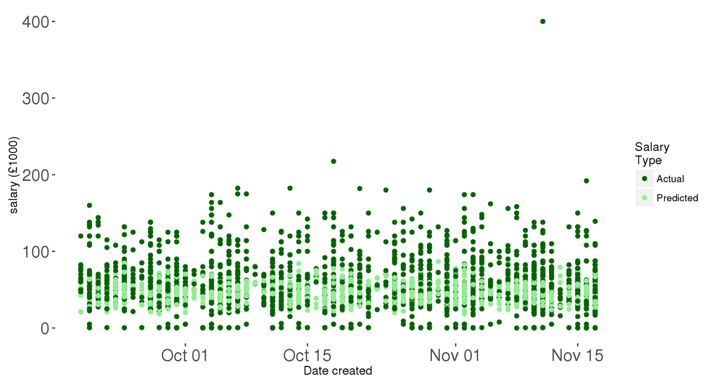

### Posting Rate

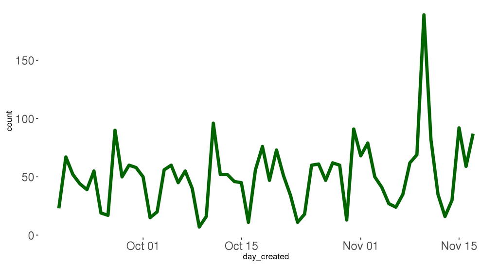

### Word Use

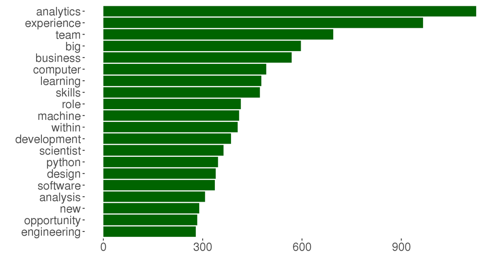

### Skills mentioned

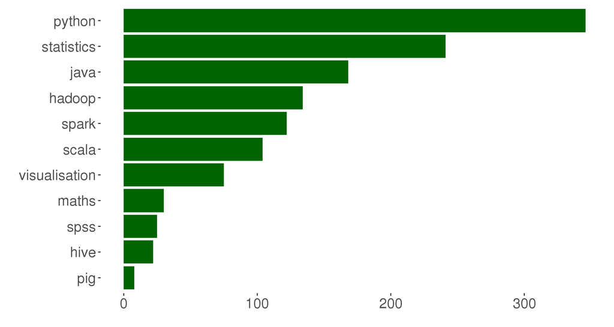

````r
---
title: "DATA SCIENCE JOB MARKET (careful: under development!)"
output:
  flexdashboard::flex_dashboard:
    orientation: columns
    social: menu
    source_code: embed
    css: theme-lumen.css
---

```{r setup, include=FALSE}
library(flexdashboard)
library(leaflet)
library(ggplot2)
library(lubridate)

d <- readRDS("/home/rpopat/AdzunaDataBot/dashboard/data/d.rds")
d_small <- readRDS("/home/rpopat/AdzunaDataBot/dashboard/data/d_small.rds")
d_map <- readRDS("/home/rpopat/AdzunaDataBot/dashboard/data/d_map.rds")
top_words <- readRDS("/home/rpopat/AdzunaDataBot/dashboard/data/top_words.rds")
skills_count <- readRDS("/home/rpopat/AdzunaDataBot/dashboard/data/skills_count.rds")

### AESTHETICS
plot_col <- "darkgreen"
plot_col_light <- "light green"
theme_stripped <- theme(
  panel.background = element_blank(),
  axis.text = element_text(size = 15)
)
```

Backgroud {.sidebar}
=======================================================================



At The Data Lab, we want to stimulate a productive data science environment. Part of this is helping the job market. To keep our fingers on the pulse of data science jobs in the UK we created this little dashboard. We query the [Adzuna](https://developer.adzuna.com/) API every night to retrieve records pertaining to "data science". An EC2 instance achieves this for us. We store this in a MySQL database (also on Amazon). This front end was created in R with [flexdashboard](http://rmarkdown.rstudio.com/flexdashboard/index.html).

If you have any questions about this or anything else we do, please head over to the [website](http://thedatalab.com/) or [get in touch](mailto:info@thedatalab.com) directly.

You can view the full project on our [github repo](https://github.com/rmnppt/AdzunaDataBot). In the fullness of time we will write a blog piece on how we set this up on AWS, but if you want to know now then get in touch with the link above.

Last update: `r Sys.time()`


![powered by Adzuna](/home/rpopat/AdzunaDataBot/logos/adzuna_logo_small.jpg)


Map
=======================================================================

Column {data-width=650}
-----------------------------------------------------------------------

### Jobs Map

```{r}
leaflet(d_map) %>%
  addProviderTiles("CartoDB.Positron", tileOptions(minZoom=10, maxZoom=17)) %>%
  addCircleMarkers(color = as.factor(d_map$still_available),
                   popup = d_map$labels) %>%
  addLegend("bottomleft",
            colors = c("darkgreen","red"),
            labels = c("Still available",
                       "Recently disappeared"),
            opacity = 0.8)
```

Column {data-width=400}
-----------------------------------------------------------------------

### Jobs currently available

```{r}
njobs <- sum(d_small$available_today)
valueBox(njobs, icon = "fa-heartbeat")
```

### Median Posts per day

```{r}
ppd <- table(d_small$day_created)
mppd <- signif(median(ppd, na.rm = TRUE), 3)
valueBox(mppd, icon = "fa-file")
```

### Median lifespan of ads (days)

```{r}
id_days <- table(d$id, d$date_queried)
dead <- which(id_days[,ncol(id_days)] == 0 & id_days[,1] == 0)
id_days_alive <- id_days[dead,]
valueBox(median(rowSums(id_days_alive)), icon = "fa-life-ring")
```

### Most popular word

```{r}
top_word <- top_words$word[1]
valueBox(paste0('"', top_word , '"'), icon = "fa-book")
```

### Median Salary (thousands £)

```{r}
med_sal <- signif(median(d_small$mean_salary_thou, na.rm = TRUE), 4)
valueBox(med_sal, icon = "fa-money")
```

### Percent permanent contracts

```{r}
contracts <- table(d_small$contract_type[!is.na(d_small$contract_type)])
perc_perm <- contracts[2] / sum(contracts) * 100
valueBox(signif(perc_perm, 3), icon = "fa-hourglass")
```



Dashboard
=======================================================================

Column {data-width=400}
-----------------------------------------------------------------------

### Salary

```{r, fig.width = 9}
ggplot(d_small, aes(x = day_created, y = mean_salary_thou)) +
  geom_point( aes(colour = salary_is_predicted), size=1.5)  +
  ylab("salary (£1000)") +
  xlab("Date created") +
  scale_colour_manual(values=c(plot_col, plot_col_light), name="Salary\nType", breaks=c("0", "1"), labels=c("Actual", "Predicted")) +
  theme_stripped
```

### Posting Rate

```{r, fig.width = 9}
ggplot(d_small, aes(x = day_created)) +
  geom_line(stat = "count", color = plot_col, size = 2) +
  theme_stripped
```


Column {data-width=400}
-----------------------------------------------------------------------

### Word Use

```{r, fig.width = 9}
ggplot(top_words[1:20, ], aes(x = reorder(word, count), y = count)) +
  geom_bar(fill = plot_col, stat = "identity") +
  ylab("") + xlab("") +
  coord_flip() +
  theme_stripped
```

### Skills mentioned
```{r, fig.width = 9}
ggplot(skills_count, aes(x = reorder(skill, count), y = count)) +
  geom_bar(fill = plot_col, stat = "identity") +
  ylab("") + xlab("") +
  coord_flip() +
  theme_stripped
```
````